## Introduction

This vignette documents the use of the `MANOVA.RM` package for the analysis of semi-parametric repeated measures designs and multivariate data. The package consists of three parts - one for repeated measurements, one for multivariate data and one for the combination of both - which will be explained in detail below. All functions calculate the Wald-type statistic (WTS) as well as the ANOVA-type statistic (ATS) for repeated measures and a modification thereof (MATS) for multivariate data based on means. These test statistics can be used for arbitrary semi-parametric designs, even with unequal covariance matrices among groups and small sample sizes. For a short overview of the test statistics and corresponding references see the next section. Furthermore, different resampling approaches are provided in order to improve the small sample behavior of the test statistics. The WTS requires non-singular covariance matrices. If the covariance matrix is singular, a warning is returned.

For detailed explanations and examples, see also Friedrich, Konietschke and Pauly (2019).

## Theoretical background

We consider the following model
$$X_{ik} = \mu_i + \varepsilon_{ik}$$
for observation vectors from group $i$ and individual $k$. Here, $\mu_i$ denotes the group mean which we wish to infer and $\varepsilon_{ik}$ are the common error terms with expectation 0 and existing (co-)variances. We do not need to assume normally distributed errors for these methods and the covariances may be unequal between groups. Null hypotheses are formulated via contrast matrices, i.e., as $H \mu = 0$, where the rows of $H$ sum to zero. Then the Wald-type statistic (WTS) is a quadratic form in the estimated mean vector involving the Moore-Penrose inverse of the (transformed) empirical covariance matrix. Under the null hypothesis the WTS is asymptotically $\chi^2$ distributed with rank(H) degrees of freedom. However, this approximation is only valid for large sample sizes, see e.g. Brunner (2001). We therefore recommend to use a resampling approach as proposed by Konietschke et al. (2015) or Friedrich et al. (2017).

Since the WTS requires non-singular covariance matrices, two other test statistics have been proposed: the ATS for repeated measures designs (Brunner, 2001) and the MATS for multivariate data (Friedrich and Pauly, 2018). The ATS is a scaled quadratic form in the mean vector, which is usually approximated by an F-distribution with estimated degrees of freedom. This approach is also implemented in the SAS PROC Mixed procedure. However, it is rather conservative for small sample sizes and does not provide an asymptotic level $\alpha$ test.

The MATS for multivariate data has the advantage of being invariant under scale transformations of the data, an important feature for multivariate data. Since its asymptotic distribution involves unknown parameters, we again propose to use bootstrap approaches instead (Friedrich and Pauly, 2018).

## Difference between RM and MANOVA design

- In a repeated measures design (RM) the same outcome is observed at different occasions, e.g., different time points or different parts of the body like left/right hemisphere of the brain. Hypotheses about the sub-plot or within-subject factors are possible.
- In a MANOVA design, d-dimensional outcome vectors are observed for every subject. These outcomes are potentially measured on different scales (e.g., kg, m, heart rate, …) and hypotheses are formulated on the whole outcome vectors. The only difference between the functions `MANOVA` and `MANOVA.wide` is the format of the data: For `MANOVA` data need to be in long format (one row per measurement), whereas `MANOVA.wide` is for data in wide format (one row per individual).

Note that a combination of both types of data, i.e., multivariate longitudinal data, can now also be analyzed with `MANOVA.RM`, see below.

## The `RM` function

The `RM` function calculates the WTS and ATS in a repeated measures design with an arbitrary number of crossed whole-plot (between-subject) and sub-plot (within-subject) factors. The resampling methods provided are a permutation procedure, a parametric bootstrap approach and a wild bootstrap using Rademacher weights. The permutation procedure provides no valid approach for the ATS and is thus not implemented.

### Data Example 1 (One between-subject and two within-subject factors)

For illustration purposes, we consider the data set `o2cons`, which is included in `MANOVA.RM`.

```r
library(MANOVA.RM)
data(o2cons)
```

The data set contains measurements on the oxygen consumption of leukocytes in the presence and absence of inactivated staphylococci at three consecutive time points. More details on the study and the statistical model can be found in Friedrich et al. (2017). Due to the study design, both time and staphylococci are within-subject factors while the treatment (Verum vs. Placebo) is a between-subject factor.

```r
head(o2cons)
```

```
##     O2 Staphylococci Time Group Subject
## 1 1.48             1    6     P       1
## 2 2.81             1   12     P       1
## 3 3.56             1   18     P       1
## 4 1.04             0    6     P       1
## 5 2.07             0   12     P       1
## 6 2.81             0   18     P       1
```

We will now analyze this data using the `RM` function. The `RM` function takes as arguments:

- `formula`: A formula consisting of the outcome variable on the left hand side of a ~ operator and the factor variables of interest on the right hand side. The within-subject factor(s) must be specified last in the formula, e.g. `outcome ~ between1 * between2 * within1 * within2`.
- `data`: A data.frame containing the variables in `formula`.
- `subject`: The column name of the subjects variable in the data frame.
- `no.subf`: The number of within-subject factors, default is 1. Alternatively, the within-subjects factors can be directly specified using `within`.
- `iter`: The number of iterations for the resampling approach. Default value is 10,000.
- `alpha`: The significance level, default is 0.05.
- `resampling`: The resampling method, one of ‘Perm’, ‘paramBS’ or ‘WildBS’. Default is set to ‘Perm’.
- `para`: A logical indicating whether parallel computing should be used. Default is `FALSE`.
- `CPU`: The number of cores used for parallel computing. If not specified, cores are detected automatically.
- `seed`: A random seed for the resampling procedure. If omitted, no reproducible seed is set. Note that the random seeds for the parallel computing differ from those without parallelisation. Thus, to reproduce results obtained with MANOVA.RM version <0.5.1, argument `para` must be set to `TRUE`.
- `CI.method`: The method for calculating the quantiles used for the confidence intervals, either ‘t-quantile’ (the default) or ‘resampling’ (based on quantile of the resampled WTS).
- `dec`: The number of decimals the results should be rounded to. Default is 3.

```r
model1 <- RM(O2 ~ Group * Staphylococci * Time, data = o2cons,
             subject = "Subject", no.subf = 2, iter = 1000,
             resampling = "Perm", seed = 1234)
summary(model1)
```

```
## Call:
## O2 ~ Group * Staphylococci * Time
## A repeated measures analysis with 2 within-subject factor(s) ( Staphylococci,Time ) and 1 between-subject factor(s).
##
## Descriptive:
##    Group Staphylococci Time  n Means Lower 95 % CI Upper 95 % CI
## 1      P             0    6 12 1.322         1.150         1.493
## 5      P             0   12 12 2.430         2.196         2.664
## 9      P             0   18 12 3.425         3.123         3.727
## 3      P             1    6 12 1.618         1.479         1.758
## 7      P             1   12 12 2.434         2.164         2.704
## 11     P             1   18 12 3.527         3.273         3.781
## 2      V             0    6 12 1.394         1.201         1.588
## 6      V             0   12 12 2.570         2.355         2.785
## 10     V             0   18 12 3.677         3.374         3.979
## 4      V             1    6 12 1.656         1.471         1.840
## 8      V             1   12 12 2.799         2.500         3.098
## 12     V             1   18 12 4.029         3.802         4.257
##
## Wald-Type Statistic (WTS):
##                          Test statistic df  p-value
## Group                    "11.167"       "1" "0.001"
## Staphylococci            "20.401"       "1" "<0.001"
## Group:Staphylococci      "2.554"        "1" "0.11"
## Time                     "4113.057"     "2" "<0.001"
## Group:Time               "24.105"       "2" "<0.001"
## Staphylococci:Time       "4.334"        "2" "0.115"
## Group:Staphylococci:Time "4.303"        "2" "0.116"
##
## ANOVA-Type Statistic (ATS):
##                          Test statistic df1     df2      p-value
## Group                    "11.167"       "1"     "57.959" "0.001"
## Staphylococci            "20.401"       "1"     "Inf"    "<0.001"
## Group:Staphylococci      "2.554"        "1"     "Inf"    "0.11"
## Time                     "960.208"      "1.524" "Inf"    "<0.001"
## Group:Time               "5.393"        "1.524" "Inf"    "0.009"
## Staphylococci:Time       "2.366"        "1.983" "Inf"    "0.094"
## Group:Staphylococci:Time "2.147"        "1.983" "Inf"    "0.117"
##
## p-values resampling:
##                          Perm (WTS)
## Group                    "<0.001"
## Staphylococci            "<0.001"
## Group:Staphylococci      "0.119"
## Time                     "<0.001"
## Group:Time               "<0.001"
## Staphylococci:Time       "0.152"
## Group:Staphylococci:Time "0.146"
```

The output consists of four parts: `model1$Descriptive` gives an overview of the descriptive statistics: The number of observations, mean and confidence intervals (based on either quantiles of the t-distribution or the resampling-based quantiles) are displayed for each factor level combination. `model1$WTS` contains the results for the Wald-type test: The test statistic, degree of freedom and p-values based on the asymptotic $\chi^2$ distribution are displayed. Note that the $\chi^2$ approximation is very liberal for small sample sizes. `model1$ATS` contains the corresponding results based on the ATS. This test statistic tends to rather conservative decisions in case of small sample sizes and is even asymptotically only an approximation, thus not providing an asymptotic level $\alpha$ test. Finally, `model1$resampling` contains the p-values based on the chosen resampling approach. For the ATS, the permutation procedure cannot be applied. Due to the above mentioned issues for small sample sizes, the resampling procedure is recommended.

### Data Example 2 (Two within-subject and two between-subject factors)

We consider the data set `EEG` from the `MANOVA.RM` package: At the Department of Neurology, University Clinic of Salzburg, 160 patients were diagnosed with either Alzheimer’s Disease (AD), mild cognitive impairments (MCI), or subjective cognitive complaints without clinically significant deficits (SCC), based on neuropsychological diagnostics (Bathke et al.(2018)). This data set contains z-scores for brain rate and Hjorth complexity, each measured at frontal, temporal and central electrode positions and averaged across hemispheres. In addition to standardization, complexity values were multiplied by -1 in order to make them more easily comparable to brain rate values: For brain rate we know that the values decrease with age and pathology, while Hjorth complexity values are known to increase with age and pathology. The three between-subject factors considered were sex (men vs. women), diagnosis (AD vs. MCI vs. SCC), and age ($< 70$ vs. $>= 70$ years). Additionally, the within-subject factors region (frontal, temporal, central) and feature (brain rate, complexity) structure the response vector.

```r
data(EEG)
EEG_model <- RM(resp ~ sex * diagnosis * feature * region,
                data = EEG, subject = "id", within = c("feature", "region"),
                resampling = "WildBS",
                iter = 1000,  alpha = 0.01, seed = 987)
summary(EEG_model)
```

```
## Call:
## resp ~ sex * diagnosis * feature * region
## A repeated measures analysis with 2 within-subject factor(s) ( feature,region ) and 2 between-subject factor(s).
##
## Descriptive:
##    sex diagnosis    feature   region  n  Means Lower 99 % CI Upper 99 % CI
## 1    M        AD  brainrate  central 12 -1.010        -4.881         2.861
## 13   M        AD  brainrate  frontal 12 -1.007        -4.991         2.977
## 25   M        AD  brainrate temporal 12 -0.987        -4.493         2.519
## 7    M        AD complexity  central 12 -1.488       -10.053         7.077
## 19   M        AD complexity  frontal 12 -1.086        -6.906         4.735
## 31   M        AD complexity temporal 12 -1.320        -7.203         4.562
## 3    M       MCI  brainrate  central 27 -0.447        -1.591         0.696
## 15   M       MCI  brainrate  frontal 27 -0.464        -1.646         0.719
## 27   M       MCI  brainrate temporal 27 -0.506        -1.584         0.572
## 9    M       MCI complexity  central 27 -0.257        -1.139         0.625
## 21   M       MCI complexity  frontal 27 -0.459        -1.997         1.079
## 33   M       MCI complexity temporal 27 -0.490        -1.796         0.816
## 5    M       SCC  brainrate  central 20  0.459        -0.414         1.332
## 17   M       SCC  brainrate  frontal 20  0.243        -0.670         1.156
## 29   M       SCC  brainrate temporal 20  0.409        -1.210         2.028
## 11   M       SCC complexity  central 20  0.349        -0.070         0.767
## 23   M       SCC complexity  frontal 20  0.095        -1.037         1.227
## 35   M       SCC complexity temporal 20  0.314        -0.598         1.226
## 2    W        AD  brainrate  central 24 -0.294        -1.978         1.391
## 14   W        AD  brainrate  frontal 24 -0.159        -1.813         1.495
## 26   W        AD  brainrate temporal 24 -0.285        -1.776         1.206
## 8    W        AD complexity  central 24 -0.128        -1.372         1.116
## 20   W        AD complexity  frontal 24  0.026        -1.212         1.264
## 32   W        AD complexity temporal 24 -0.194        -1.670         1.283
## 4    W       MCI  brainrate  central 30 -0.106        -1.076         0.863
## 16   W       MCI  brainrate  frontal 30 -0.074        -1.032         0.885
## 28   W       MCI  brainrate temporal 30 -0.069        -1.064         0.925
## 10   W       MCI complexity  central 30  0.094        -0.464         0.652
## 22   W       MCI complexity  frontal 30  0.131        -0.768         1.031
## 34   W       MCI complexity temporal 30  0.121        -0.652         0.895
## 6    W       SCC  brainrate  central 47  0.537        -0.049         1.124
## 18   W       SCC  brainrate  frontal 47  0.548        -0.062         1.159
## 30   W       SCC  brainrate temporal 47  0.559        -0.015         1.133
## 12   W       SCC complexity  central 47  0.384         0.110         0.659
```

[output cut: 41 more lines]

```
## sex                          "0.006"      "0.006"
## diagnosis                    "<0.001"     "<0.001"
## sex:diagnosis                "0.175"      "0.169"
## feature                      "0.768"      "0.768"
## sex:feature                  "0.145"      "0.145"
## diagnosis:feature            "0.082"      "0.255"
## sex:diagnosis:feature        "0.474"      "0.386"
## region                       "0.976"      "0.987"
## sex:region                   "0.703"      "0.713"
## diagnosis:region             "0.198"      "0.366"
## sex:diagnosis:region         "0.86"       "0.825"
## feature:region               "0.8"        "0.938"
## sex:feature:region           "0.885"      "0.942"
## diagnosis:feature:region     "0.145"      "0.523"
## sex:diagnosis:feature:region "0.75"       "0.668"
```

We find significant effects at level $\alpha = 0.01$ of the between-subject factors sex and diagnosis, while none of the within-subject factors or interactions become significant.

### Plotting

The `RM()` function is equipped with a plotting option, displaying the calculated means along with the $(1-\alpha)$ confidence intervals. The `plot` function takes an `RM` object as an argument. Furthermore, additional graphical parameters can be used to customize the plots. The optional argument `legendpos` specifies the position of the legend in higher-way layouts, while the argument `gap` (default 0.1) specifies the distance between the error bars.

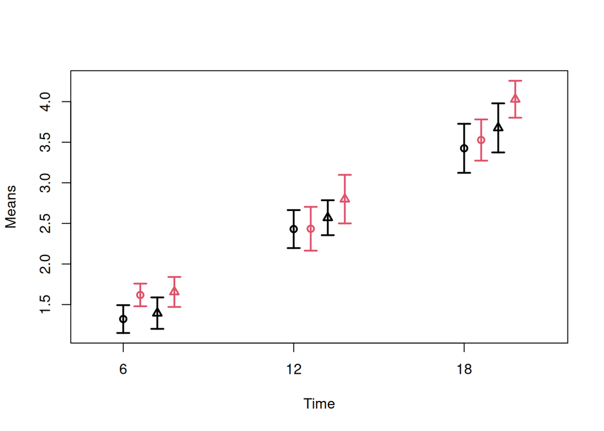

```r
plot(model1, leg = FALSE)
```

For illustration purposes, we reduce the EEG-model above to a two-way design:

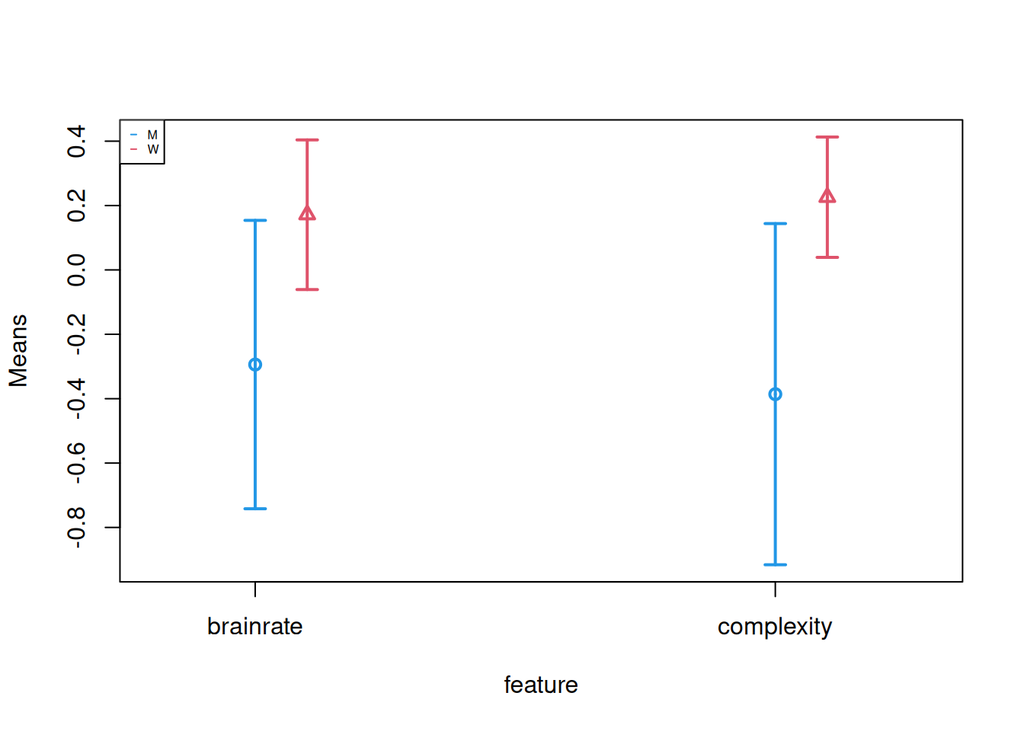

```r
EEGnew <- EEG[EEG$region == "temporal", ]
EEG_model2 <- RM(resp ~ sex*feature, within = "feature", no.subf = 1, subject = "id", data = EEGnew)
plot(EEG_model2, legendpos = "topleft", col = c(4, 2))
```

## The `MANOVA` function

The `MANOVA` function calculates the WTS for multivariate data in a design with crossed or nested factors. Additionally, a modified ANOVA-type statistic (MATS) is calculated which has the additional advantage of being applicable to designs involving singular covariance matrices and is invariant under scale transformations of the data, see Friedrich and Pauly (2018) for details. The resampling methods provided are a parametric bootstrap approach and a wild bootstrap using Rademacher weights. Note that only balanced nested designs (i.e., the same number of factor levels $b$ for each level of the factor $A$) with up to three factors are implemented. Designs involving both crossed and nested factors are not implemented. Data must be provided in long format (for wide format, see `MANOVA.wide` below).

### Data Example MANOVA (two crossed factors)

We again consider the data set `EEG` from the `MANOVA.RM` package, but now we ignore the within-subject factors. Therefore, we are now in a multivariate setting with 6 measurements per patient and three crossed factors sex, age and diagnosis. Due to the small number of subjects in some groups (e.g., only 2 male patients aged $<$ 70 were diagnosed with AD) we restrict our analyses to two factors at a time. The analysis of this example is shown below.

The most important arguments of the `MANOVA` function are:

- `formula`: A formula consisting of the outcome variable on the left hand side of a ~ operator and the factor variables of interest on the right hand side.
- `data`: A data.frame containing the variables in `formula`.
- `subject`: The column name of the subjects variable in the data frame.
- `resampling`: The resampling method, one of ‘paramBS’ and ‘WildBS’. Default is set to ‘paramBS’.
- `nested.levels.unique`: For nested designs only: A logical specifying whether the levels of the nested factor(s) are labeled uniquely or not. Default is FALSE, i.e., the levels of the nested factor are the same for each level of the main factor. For an example and more explanations see the GFD package and the corresponding vignette.

```r
data(EEG)
EEG_MANOVA <- MANOVA(resp ~ sex * diagnosis,
                     data = EEG, subject = "id", resampling = "paramBS",
                     iter = 1000,  alpha = 0.01, seed = 987)
summary(EEG_MANOVA)
```

```
## Call:
## resp ~ sex * diagnosis
##
## Descriptive:
##   sex diagnosis  n Mean 1 Mean 2 Mean 3 Mean 4 Mean 5 Mean 6
## 1   M        AD 12 -0.987 -1.007 -1.010 -1.320 -1.086 -1.488
## 3   M       MCI 27 -0.506 -0.464 -0.447 -0.490 -0.459 -0.257
## 5   M       SCC 20  0.409  0.243  0.459  0.314  0.095  0.349
## 2   W        AD 24 -0.285 -0.159 -0.294 -0.194  0.026 -0.128
## 4   W       MCI 30 -0.069 -0.074 -0.106  0.121  0.131  0.094
## 6   W       SCC 47  0.559  0.548  0.537  0.506  0.403  0.384
##
## Wald-Type Statistic (WTS):
##               Test statistic df   p-value
## sex           "12.604"       "6"  "0.05"
## diagnosis     "55.158"       "12" "<0.001"
## sex:diagnosis "9.79"         "12" "0.634"
##
## modified ANOVA-Type Statistic (MATS):
##               Test statistic
## sex                   45.263
## diagnosis            194.165
## sex:diagnosis         18.401
##
## p-values resampling:
##               paramBS (WTS) paramBS (MATS)
## sex           "0.127"       "0.006"
## diagnosis     "<0.001"      "<0.001"
## sex:diagnosis "0.739"       "0.217"
```

The output consists of several parts: First, some descriptive statistics of the data set are displayed, namely the sample size and mean for each factor level combination and each dimension. (Dimensions occur in the same order as in the original data set. For a labeled output, use `MANOVA.wide()`.) In this example, Mean 1 to Mean 3 correspond to the brainrate (temporal, frontal, central) while Mean 4–6 correspond to complexity. Second, the results based on the WTS are displayed. For each factor, the test statistic, degree of freedom and p-value is given. For the MATS, only the value of the test statistic is given, since inference is here based on the resampling procedure only. The resampling-based p-values are finally displayed for both test statistics.

### The `MANOVA.wide` function

The `MANOVA.wide` function is used for data provided in wide format, i.e., with one row per unit. Input and output are almost identical to the `MANOVA` function, except that no `subject` variable needs to be specified. The formula now consists of the matrix of outcome variables (bound together via `cbind()`) on the left hand side of the ~ operator and the factors of interest on the right. For an example we use a data set on producing plastic film from Krzanowski (1998, p. 381), see also `summary.manova`:

```r
tear <- c(6.5, 6.2, 5.8, 6.5, 6.5, 6.9, 7.2, 6.9, 6.1, 6.3,
          6.7, 6.6, 7.2, 7.1, 6.8, 7.1, 7.0, 7.2, 7.5, 7.6)
gloss <- c(9.5, 9.9, 9.6, 9.6, 9.2, 9.1, 10.0, 9.9, 9.5, 9.4,
           9.1, 9.3, 8.3, 8.4, 8.5, 9.2, 8.8, 9.7, 10.1, 9.2)
opacity <- c(4.4, 6.4, 3.0, 4.1, 0.8, 5.7, 2.0, 3.9, 1.9, 5.7,
             2.8, 4.1, 3.8, 1.6, 3.4, 8.4, 5.2, 6.9, 2.7, 1.9)
rate     <- gl(2,10, labels = c("Low", "High"))
additive <- gl(2, 5, length = 20, labels = c("Low", "High"))

example <- data.frame(tear, gloss, opacity, rate, additive)
fit <- MANOVA.wide(cbind(tear, gloss, opacity) ~ rate * additive, data = example, iter = 1000)
summary(fit)
```

```
## Call:
## cbind(tear, gloss, opacity) ~ rate * additive
##
## Descriptive:
##   rate additive n tear  gloss  opacity
## 1  Low      Low 5 6.30   9.56     3.74
## 2  Low     High 5 6.68   9.58     3.84
## 3 High      Low 5 6.88   8.72     3.14
## 4 High     High 5 7.28   9.40     5.02
##
## Wald-Type Statistic (WTS):
##               Test statistic df  p-value
## rate          "25.9"         "3" "<0.001"
## additive      "14.591"       "3" "0.002"
## rate:additive "4.589"        "3" "0.204"
##
## modified ANOVA-Type Statistic (MATS):
##               Test statistic
## rate                  23.808
## additive              11.835
## rate:additive          4.296
##
## p-values resampling:
##               paramBS (WTS) paramBS (MATS)
## rate          "0.005"       "0.001"
## additive      "0.026"       "0.04"
## rate:additive "0.31"        "0.274"
```

### Confidence regions

A function for calculating and plotting of confidence regions is available for `MANOVA` objects. Details on the methods can be found in Friedrich and Pauly (2018).

#### Confidence regions

Confidence regions can be calculated using the `conf.reg` function. Note that confidence regions can only be plotted in designs with 2 dimensions. The `conf.reg` function takes as arguments:

- `object`: A `MANOVA` object calculated via `MANOVA()` or `MANOVA.wide()`.
- `nullhypo`: In designs involving more than one factor, it is necessary to specify the null hypothesis, i.e., the contrast of interest.

As an example, we consider the data set `water` from the package `HSAUR3`. The data set contains measurements of mortality and drinking water hardness for 61 cities in England and Wales. Suppose we want to analyse whether these measurements differ between northern and southern towns. Since the data set is in wide format, we need to use the `MANOVA.wide` function.

```
## Call:
## cbind(mortality, hardness) ~ location
##
## Descriptive:
##   location  n mortality  hardness
## 1    North 35  1633.600    30.400
## 2    South 26  1376.808    69.769
##
## Wald-Type Statistic (WTS):
##          Test statistic df  p-value
## location "51.584"       "2" "<0.001"
##
## modified ANOVA-Type Statistic (MATS):
##          Test statistic
## location         69.882
##
## p-values resampling:
##          paramBS (WTS) paramBS (MATS)
## location "<0.001"      "<0.001"
```

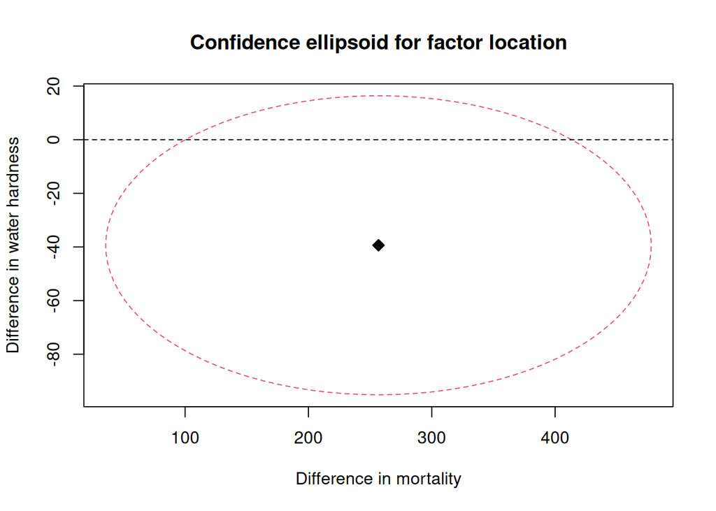

```r
if (requireNamespace("HSAUR3", quietly = TRUE)) {
library(HSAUR3)
data(water)
test <- MANOVA.wide(cbind(mortality, hardness) ~ location, data = water, iter = 1000, resampling = "paramBS", seed = 123)
summary(test)
cr <- conf.reg(test)
cr
plot(cr, col = 2, lty = 2, xlab = "Difference in mortality", ylab ="Difference in water hardness")
}
```

### Post-hoc comparisons

#### Multivariate post-hoc comparisons and simultaneous confidence intervals for contrasts

Calculation of simultaneous confidence intervals and multivariate p-values for contrasts of the mean vector is based on the sum statistic, see Friedrich and Pauly (2018) for details. Note that the confidence intervals and p-values returned are simultaneous, i.e., they maintain the given alpha-level. Confidence intervals are calculated based on summary effects, i.e., averaging over all dimensions, whereas the returned p-values are multivariate. If the original model contains more than one factor, the corresponding contrasts are calculated for all combinations of factor levels. If this is not desired, the parameter `interaction` may be set to FALSE and the factor of interest specified. This has the same effect as fitting the model with only the respective factor and then calculating the post-hoc tests based on this model. The function `simCI` takes the following arguments:

- `object`: A `MANOVA` object calculated via `MANOVA()` or `MANOVA.wide()`.
- `contrast`: The contrast of interest, can either be “pairwise” or “user-defined”.
- `contmat`: For user-defined contrasts, the contrast matrix must be specified here. Note that its rows must sum to zero.
- `type`: Pairwise contrasts are calculated based on the contrMat function in package multcomp, see also the corresponding help page. The type of the pairwise comparison must be specified here.
- `base`: an integer specifying which group is considered the baseline group for Dunnett contrasts, see also the documentation of `contrMat()` from the multcomp-package.
- `interaction`: Logical. If interaction = FALSE in models with more than one factor, the factor of interest for the post-hoc analysis must be specified. Default is TRUE, which means post-hoc tests are performed for all factor level combinations.
- `factor`: Only needed if interaction = FALSE. Specifies the factor for which post-hoc analysis are requested.
- `silent`: Set to TRUE to suppress output.

As an example, we consider the `EEG_MANOVA` example from above:

```r
# pairwise comparison using Tukey contrasts
simCI(EEG_MANOVA, contrast = "pairwise", type = "Tukey")
```

```
##
##  #------ Call -----#
##
##  - Contrast:  Tukey
##  - Confidence level: 99 %
##
##  #------Multivariate post-hoc comparisons: p-values -----#
##
##         contrast p.value
## 1   M MCI - M AD   0.972
## 2   M SCC - M AD   0.570
## 3    W AD - M AD   0.884
## 4   W MCI - M AD   0.770
## 5   W SCC - M AD   0.428
## 6  M SCC - M MCI   0.371
## 7   W AD - M MCI   0.995
## 8  W MCI - M MCI   0.840
## 9  W SCC - M MCI   0.112
## 10  W AD - M SCC   0.845
## 11 W MCI - M SCC   0.941
## 12 W SCC - M SCC   0.992
## 13  W MCI - W AD   0.997
## 14  W SCC - W AD   0.539
## 15 W SCC - W MCI   0.583
##
##  #-----------Confidence intervals for summary effects-------------#
##
##               Estimate      Lower     Upper
## M MCI - M AD     4.275 -15.330609 23.880609
## M SCC - M AD     8.767 -10.298844 27.832844
## W AD - M AD      5.864 -14.081926 25.809926
## W MCI - M AD     6.995 -12.147385 26.137385
## W SCC - M AD     9.835  -8.982681 28.652681
## M SCC - M MCI    4.492  -3.685235 12.669235
## W AD - M MCI     1.589  -8.470857 11.648857
## W MCI - M MCI    2.720  -5.634142 11.074142
## W SCC - M MCI    5.560  -2.020627 13.140627
## W AD - M SCC    -2.903 -11.865545  6.059545
## W MCI - M SCC   -1.772  -8.766153  5.222153
## W SCC - M SCC    1.068  -4.981165  7.117165
## W MCI - W AD     1.131  -7.993239 10.255239
## W SCC - W AD     3.971  -4.450754 12.392754
## W SCC - W MCI    2.840  -3.446248  9.126248
```

A one-way layout using MANOVA.wide():

```r
oneway <- MANOVA.wide(cbind(brainrate_temporal, brainrate_central) ~ diagnosis, data = EEGwide, iter = 1000)
# and a user-defined contrast matrix
H <- as.matrix(cbind(rep(1, 5), -1*Matrix::Diagonal(5)))
# user-specified comparison
simCI(oneway, contrast = "user-defined", contmat = H)
```

```
##
##  #------ Call -----#
##
##  - Contrast:  user-defined
##  - Confidence level: 95 %
##
##  #------Multivariate post-hoc comparisons: p-values -----#
##
## [1] 1.000 0.685 0.665 0.012 0.006
##
##  #-----------Confidence intervals for summary effects-------------#
##
##   Estimate      Lower      Upper
## 1    0.013 -0.9462296  0.9722296
## 2   -0.243 -1.0046345  0.5186345
## 3   -0.251 -1.0128958  0.5108958
## 4   -1.033 -1.7686629 -0.2973371
## 5   -1.033 -1.7490081 -0.3169919
```

#### Univariate comparisons

If the global null hypothesis is rejected, it may be of interest to infer the univariate outcomes that caused the rejection. To answer this question, one can simply calculate the univariate p-values and adjust them accordingly for multiple testing, e.g., using Bonferroni-correction. An example is given below. We consider a one-way layout of the EEG data with influencing factor sex and all 6 outcome variables:

```r
model_sex <- MANOVA.wide(cbind(brainrate_temporal, brainrate_central, brainrate_frontal,
                            complexity_temporal, complexity_central, complexity_frontal) ~ sex, data = EEGwide, iter = 1000, seed = 987)
summary(model_sex)
```

```
## Call:
## cbind(brainrate_temporal, brainrate_central, brainrate_frontal,
##     complexity_temporal, complexity_central, complexity_frontal) ~
##     sex
##
## Descriptive:
##   sex   n brainrate_temporal  brainrate_central  brainrate_frontal
## 1   M  59             -0.294             -0.254             -0.335
## 2   W 101              0.172              0.149              0.195
##    complexity_temporal  complexity_central  complexity_frontal
## 1               -0.386              -0.302              -0.399
## 2                0.226               0.176               0.233
##
## Wald-Type Statistic (WTS):
##     Test statistic df  p-value
## sex "15.382"       "6" "0.017"
##
## modified ANOVA-Type Statistic (MATS):
##     Test statistic
## sex         55.725
##
## p-values resampling:
##     paramBS (WTS) paramBS (MATS)
## sex "0.033"       "<0.001"
```

Since the global hypothesis is rejected at 5% level, we continue with the univariate calculations:

```r
EEG1 <- MANOVA.wide(brainrate_temporal ~ sex, data = EEGwide, iter = 1000, seed = 987)
EEG2 <- MANOVA.wide(brainrate_central ~ sex, data = EEGwide, iter = 1000, seed = 987)
EEG3 <- MANOVA.wide(brainrate_frontal ~ sex, data = EEGwide, iter = 1000, seed = 987)
EEG4 <- MANOVA.wide(complexity_temporal ~ sex, data = EEGwide, iter = 1000, seed = 987)
EEG5 <- MANOVA.wide(complexity_central ~ sex, data = EEGwide, iter = 1000, seed = 987)
EEG6 <- MANOVA.wide(complexity_frontal ~ sex, data = EEGwide, iter = 1000, seed = 987)
```

Adjust for multiple testing using the parametric bootstrap MATS and Bonferroni adjustment:

```r
p.adjust(c(EEG1$resampling[, 2], EEG2$resampling[, 2], EEG3$resampling[, 2],
           EEG4$resampling[, 2], EEG5$resampling[, 2], EEG6$resampling[, 2]),
         method = "bonferroni")
```

```
## [1] 0.024 0.096 0.006 0.006 0.066 0.000
```

This reveals that the central variables (comparison 2 and 5) do not contribute to the significant difference between male and female patients.

### Nested Design

To create a data example for a nested design, we use the `curdies` data set from the `GFD` package and extend it by introducing an artificial second outcome variable. In this data set, the levels of the nested factor (site) are named uniquely, i.e., levels 1-3 of factor site belong to “WINTER”, whereas levels 4-6 belong to “SUMMER”. Therefore, `nested.levels.unique` must be set to TRUE. The code for the analysis using both wide and long format is presented below.

```r
if (requireNamespace("GFD", quietly = TRUE)) {
library(GFD)
data(curdies)
set.seed(123)
curdies$dug2 <- curdies$dugesia + rnorm(36)

# first possibility: MANOVA.wide
fit1 <- MANOVA.wide(cbind(dugesia, dug2) ~ season + season:site, data = curdies, iter = 1000, nested.levels.unique = TRUE, seed = 123)

# second possibility: MANOVA (long format)
dug <- c(curdies$dugesia, curdies$dug2)
season <- rep(curdies$season, 2)
site <- rep(curdies$site, 2)
curd <- data.frame(dug, season, site, subject = rep(1:36, 2))

fit2 <- MANOVA(dug ~ season + season:site, data = curd, subject = "subject", nested.levels.unique = TRUE, seed = 123, iter = 1000)

# comparison of results
summary(fit1)
summary(fit2)
}
```

```
## Call:
## cbind(dugesia, dug2) ~ season + season:site
##
## Descriptive:
##         season site n dugesia   dug2
## 1 SUMMER          4 6   0.419 -0.050
## 2 SUMMER          5 6   0.229  0.028
## 3 SUMMER          6 6   0.194  0.763
## 4 WINTER          1 6   2.049  2.497
## 5 WINTER          2 6   4.182  4.123
## 6 WINTER          3 6   0.678  0.724
##
## Wald-Type Statistic (WTS):
##             Test statistic df  p-value
## season      "6.999"        "2" "0.03"
## season:site "16.621"       "8" "0.034"
##
## modified ANOVA-Type Statistic (MATS):
##             Test statistic
## season              12.296
## season:site         15.064
##
## p-values resampling:
##             paramBS (WTS) paramBS (MATS)
## season      "0.064"       "0.036"
## season:site "0.305"       "0.249"
## Call:
## dug ~ season + season:site
##
## Descriptive:
##         season site n Mean 1 Mean 2
## 1 SUMMER          4 6  0.419 -0.050
## 2 SUMMER          5 6  0.229  0.028
## 3 SUMMER          6 6  0.194  0.763
## 4 WINTER          1 6  2.049  2.497
## 5 WINTER          2 6  4.182  4.123
## 6 WINTER          3 6  0.678  0.724
##
## Wald-Type Statistic (WTS):
##             Test statistic df  p-value
## season      "6.999"        "2" "0.03"
## season:site "16.621"       "8" "0.034"
##
## modified ANOVA-Type Statistic (MATS):
##             Test statistic
## season              12.296
## season:site         15.064
##
## p-values resampling:
##             paramBS (WTS) paramBS (MATS)
## season      "0.064"       "0.036"
## season:site "0.305"       "0.249"
```

## The multRM() function

The `multRM()` function provides a combination of the approaches described above. It is suitable for repeated measures designs, in which multiple outcomes have been recorded at each time point. The `multRM()` function takes as arguments:

- `formula`: A model formula object. The left hand side contains the matrix of response variables (using cbind()) and the right hand side contains the factor variables of interest. The within-subject factor(s) must be specified last in the formula, e.g. `cbind(outcome1, outcome2) ~ between1 * between2 * within1 * within2`.
- `data`: A data.frame, list or environment containing the variables in `formula`. Data must be in long format and must not contain missing values.
- `subject`: The column name of the subjects in the data. NOTE: Subjects within different groups of between-subject factors must have individual labels.
- `within`: Specifies the within-subject factor(s) in the formula.
- `iter`: The number of iterations used for calculating the resampled statistic. The default option is 10,000.
- `alpha`: A number specifying the significance level; the default is 0.05.
- `resampling`: The resampling method to be used, one of “paramBS” (parametric bootstrap approach) and “WildBS” (wild bootstrap approach with Rademacher weights).
- `para`: Logical, indicating whether parallel computing should be used. Default is FALSE.
- `CPU`: The number of cores used for parallel computing. If omitted, cores are detected automatically.
- `seed`: A random seed for the resampling procedure. If omitted, no reproducible seed is set.
- `dec`: Number of decimals the results should be rounded to. Default is 3.

As an example, we again use the EEG dataset. This time, imagine we have two outcomes (brainrate and complexity) measured for each of the three regions (within-subject factor). We additionally consider the between-subject factor sex. The `tidyr` package can be used to transform our original data to this format.

```r
if (requireNamespace("tidyr", quietly = TRUE)) {
library(tidyr)
eeg <- spread(EEG, feature, resp)
head(eeg)
fit <- multRM(cbind(brainrate, complexity) ~ sex * region, data = eeg, subject = "id", within = "region", iter = 1000)
summary(fit)
}
```

```
## Call:
## cbind(brainrate, complexity) ~ sex * region
## A multivariate repeated measures analysis with  1 within-subject factor(s) ( region )and  1 between-subject factor(s).
##
## Descriptive:
##   sex   region   n brainrate  complexity
## 1   M  central  59    -0.254      -0.302
## 2   M  frontal  59    -0.335      -0.399
## 3   M temporal  59    -0.294      -0.386
## 4   W  central 101     0.149       0.176
## 5   W  frontal 101     0.195       0.233
## 6   W temporal 101     0.172       0.226
##
## Wald-Type Statistic (WTS):
##            Test statistic df  p-value
## sex        "12.45"        "2" "0.002"
## region     "0.192"        "4" "0.996"
## sex:region "2.79"         "4" "0.593"
##
## modified ANOVA-Type Statistic (MATS):
##            Test statistic
## sex                54.203
## region              0.048
## sex:region          0.703
##
## p-values resampling:
##            paramBS (WTS) paramBS (MATS)
## sex        "0.001"       "<0.001"
## region     "0.998"       "0.988"
## sex:region "0.609"       "0.431"
```

The output is similar to that of `MANOVA()` described above.

## Which resampling approach should I choose?

The `MANOVA.RM` package provides different resampling approaches, which in some cases might lead to different conclusions. So the question is: for a given research question, which resampling approach is most appropriate? Some results from the literature giving guidance on this issue are summarized below:

- Geroldinger et al. (2026) conducted a neutral comparison study on approaches for analyzing multivariate data, including the approaches implemented in MANOVA.RM. They found the parametric bootstrap approach for the MATS to combine appropriate type-I error control with competitive power across a range of scenarios.

## References

- Bathke, A. et al. (2018). Testing Mean Differences among Groups: Multivariate and Repeated Measures Analysis with Minimal Assumptions. Multivariate Behavioral Research, 53(3), 348-359, DOI: 10.1080/00273171.2018.1446320.
- Brunner, E. (2001). Asymptotic and approximate analysis of repeated measures designs under heteroscedasticity. Mathematical Statistics with Applications in Biometry.
- Friedrich, S., Brunner, E. and Pauly, M. (2017). Permuting longitudinal data in spite of the dependencies. Journal of Multivariate Analysis, 153, 255-265.
- Friedrich, S., and Pauly, M. (2018). MATS: Inference for potentially singular and heteroscedastic MANOVA. Journal of Multivariate Analysis, 165, 166-179, DOI: 10.1016/j.jmva.2017.12.008.
- Friedrich, S., Konietschke, F., and Pauly, M. (2019). Resampling-Based Analysis of Multivariate Data and Repeated Measures Designs with the R Package MANOVA.RM. The R Journal, 11(2), 380-400.
- Konietschke, F., Bathke, A. C., Harrar, S. W. and Pauly, M. (2015). Parametric and nonparametric bootstrap methods for general MANOVA. Journal of Multivariate Analysis, 140, 291-301.
- Geroldinger, M., Laimer, M., Wally, V., Bauer, J.W., and Zimmermann, G. (2026). A neutral comparison of multivariate hypothesis tests for parallel group designs in rare disease settings. Statistics in Medicine.